# Tugas Analisis Regresi K1

Elke Frida Rahmawati - G1401221025

2024-03-05

## Data

```r
bookdown::pdf_document2
```

[output not shown]

```r
library(car)
library(dplyr)
library(readxl)
data_ar<-read_xlsx("C:/Users/user/OneDrive/Dokumen/semester 4/Data.xlsx")
data_ar
```

| no | x | y |
| --- | --- | --- |
| 1 | 2 | 54 |
| 2 | 5 | 50 |
| 3 | 7 | 45 |
| 4 | 10 | 37 |
| 5 | 14 | 35 |
| 6 | 19 | 25 |
| 7 | 26 | 20 |
| 8 | 31 | 16 |
| 9 | 34 | 18 |
| 10 | 38 | 13 |

[output cut: 5 more lines]

```r
View(data_ar)
```

## Eksplorasi Data

```r
library(GGally)
library(psych)
```

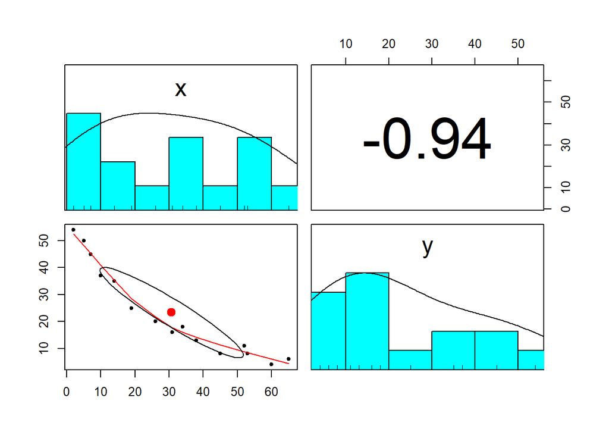

```r
pairs.panels(data_ar<-data_ar[,-1])
```

## Pemodelan Regresi

```r
reg_ar<-lm(y~x, data=data_ar)
summary(reg_ar)
```

```
##
## Call:
## lm(formula = y ~ x, data = data_ar)
##
## Residuals:
##     Min      1Q  Median      3Q     Max
## -7.1628 -4.7313 -0.9253  3.7386  9.0446
##
## Coefficients:
##             Estimate Std. Error t value Pr(>|t|)
## (Intercept) 46.46041    2.76218   16.82 3.33e-10 ***
## x           -0.75251    0.07502  -10.03 1.74e-07 ***
## ---
## Signif. codes:  0 '***' 0.001 '**' 0.01 '*' 0.05 '.' 0.1 ' ' 1
##
## Residual standard error: 5.891 on 13 degrees of freedom
## Multiple R-squared:  0.8856, Adjusted R-squared:  0.8768
## F-statistic: 100.6 on 1 and 13 DF,  p-value: 1.736e-07
```

Diperoleh metode regresi awal sebelum pemilihan metode regresi terbaik, yaitu sebagai berikut.
$$\hat{Y}=46.46041-0.75251X$$

## Uji Asumsi Model

### Uji Normalitas

Hipotesis:
$$H_0 :\ Data\ menyebar\ secara\ normal\ (p-value > {\alpha}) \\
H_1 :\ Data\ menyebar\ secara\ tidak\ normal\ (p-value \leq {\alpha}) \$$

```r
shapiro.test(data_ar$y)
```

```
##
##  Shapiro-Wilk normality test
##
## data:  data_ar$y
## W = 0.89636, p-value = 0.08374
```

$$Dengan\ {\alpha}=0.05,\ dapat\
diputuskan\ bahwa\ H_0\ diterima\ karena\ (p-value=0.08374 >
{\alpha}=0.05), \ sehingga\ dapat\ diputuskan\ bahwa\ data\ menyebar\
secara\ normal.$$

### Uji Multikolinieritas

Uji multikolinearitas tidak dapat dilakukan karena variabel independen yang ada dalam data hanya satu yaitu variabel x. Artinya tidak ada multikolinearitas antarpeubah bebas. Oleh karena itu, di bawah hanya dicantumkan perhitungan koefisien korelasi Pearson. Koefisien korelasi Pearson mengukur seberapa kuat dan searah hubungan linear antara dua variabel.

```r
correlation <- cor(data_ar$x, data_ar$y)
correlation
```

```
## [1] -0.9410528
```

Nilai yang diperoleh adalah -0.94 dimana dapat diartikan bahwa kedua variabel memiliki hubungan negatif yang sangat kuat antara dua variabel.

## Uji Homoskedastisitas

Hipotesis:
$$H_0 :\ Ragam\ galat\ bersifat\ homoskedastisitas\ (p-value >
{\alpha}) \\
H_1 :\ Ragam\ galat\ bersifat\ heteroskedastisitas\ (p-value \leq
{\alpha}) \$$

```r
lmtest::bptest(reg_ar)
```

```
##
##  studentized Breusch-Pagan test
##
## data:  reg_ar
## BP = 0.52819, df = 1, p-value = 0.4674
```

$$Dengan\ {\alpha}=0.05,\ dapat\
diputuskan\ bahwa\ H_0\ diterima\ karena\ (p-value=0.4674 >
{\alpha}=0.05), \ sehingga\ dapat\ diputuskan\ bahwa\ ragam\ galat\
bersifat\ homoskedastisitas.$$

## Uji Autokorelasi

Hipotesis:
$$H_0 :E\ [{ε_i,ε_j}]=0\ (tidak\ ada\ autokorelasi)\\
H_1 :E\ [{ε_i,ε_j}]\neq0\ (ada\ autokorelasi)\\$$

```r
lmtest::dwtest(reg_ar)
```

```
##
##  Durbin-Watson test
##
## data:  reg_ar
## DW = 0.48462, p-value = 1.333e-05
## alternative hypothesis: true autocorrelation is greater than 0
```

# Seleksi Peubah/Pemilihan Model Regresi Terbaik

## Metode Backward

```r
olsrr::ols_step_backward_p(reg_ar)
```

```
## [1] "No variables have been removed from the model."
```

Tidak ada variabel yang dihilangkan karena hanya ada satu variabel independen sehingga tidak ada variabel lain yang dapat dihapus.

## Metode Forward

```r
olsrr::ols_step_forward_p(reg_ar)
```

```
##
##
##                              Stepwise Summary
## ------------------------------------------------------------------------
## Step    Variable        AIC        SBC       SBIC       R2       Adj. R2
## ------------------------------------------------------------------------
##  0      Base Model    130.144    131.560    84.333    0.00000    0.00000
##  1      x              99.626    101.750    57.626    0.88558    0.87678
## ------------------------------------------------------------------------
##
## Final Model Output
## ------------------
##
##                          Model Summary
## ---------------------------------------------------------------
## R                       0.941       RMSE                 5.484
## R-Squared               0.886       MSE                 34.707
## Adj. R-Squared          0.877       Coef. Var           25.248
## Pred R-Squared          0.839       AIC                 99.626
## MAE                     4.852       SBC                101.750
## ---------------------------------------------------------------
##  RMSE: Root Mean Square Error
##  MSE: Mean Square Error
##  MAE: Mean Absolute Error
##  AIC: Akaike Information Criteria
##  SBC: Schwarz Bayesian Criteria
##
##                                 ANOVA
## ---------------------------------------------------------------------
##                 Sum of
##                Squares        DF    Mean Square       F         Sig.
## ---------------------------------------------------------------------
## Regression    3492.139         1       3492.139    100.617    0.0000
## Residual       451.195        13         34.707
## Total         3943.333        14
## ---------------------------------------------------------------------
##
##                                    Parameter Estimates
## -----------------------------------------------------------------------------------------
##       model      Beta    Std. Error    Std. Beta       t        Sig      lower     upper
## -----------------------------------------------------------------------------------------
## (Intercept)    46.460         2.762                  16.820    0.000    40.493    52.428
##           x    -0.753         0.075       -0.941    -10.031    0.000    -0.915    -0.590
## -----------------------------------------------------------------------------------------
```

Selain karena alasan hanya ada variabel independen, nilai-t hitung yang diperoleh < tingkat signifikansi, maka variabel x dapat dianggap signifikan dalam model. Oleh karena itu, tidak ada proses eliminasi variabel yang dapat dilakukan.

## Metode Stepwise

```r
step(lm(y~x,data=data_ar),direction="both")
```

```
## Start:  AIC=55.06
## y ~ x
##
##        Df Sum of Sq    RSS    AIC
## <none>               451.2 55.058
## - x     1    3492.1 3943.3 85.576
```

```
##
## Call:
## lm(formula = y ~ x, data = data_ar)
##
## Coefficients:
## (Intercept)            x
##     46.4604      -0.7525
```

```r
reg_ar <- lm(y ~ x, data = data_ar)
reg_ar
```

```
##
## Call:
## lm(formula = y ~ x, data = data_ar)
##
## Coefficients:
## (Intercept)            x
##     46.4604      -0.7525
```

Jika hanya ada satu variabel independen (x) dan satu variabel dependen (y), maka metode stepwise tidak akan bermanfaat karena tidak ada pilihan untuk menambah atau menghapus variabel independen dari model. Metode stepwise biasanya digunakan untuk memilih subset terbaik dari sekumpulan variabel independen yang tersedia.

# Penyesuaian Data

## Transformasi Data

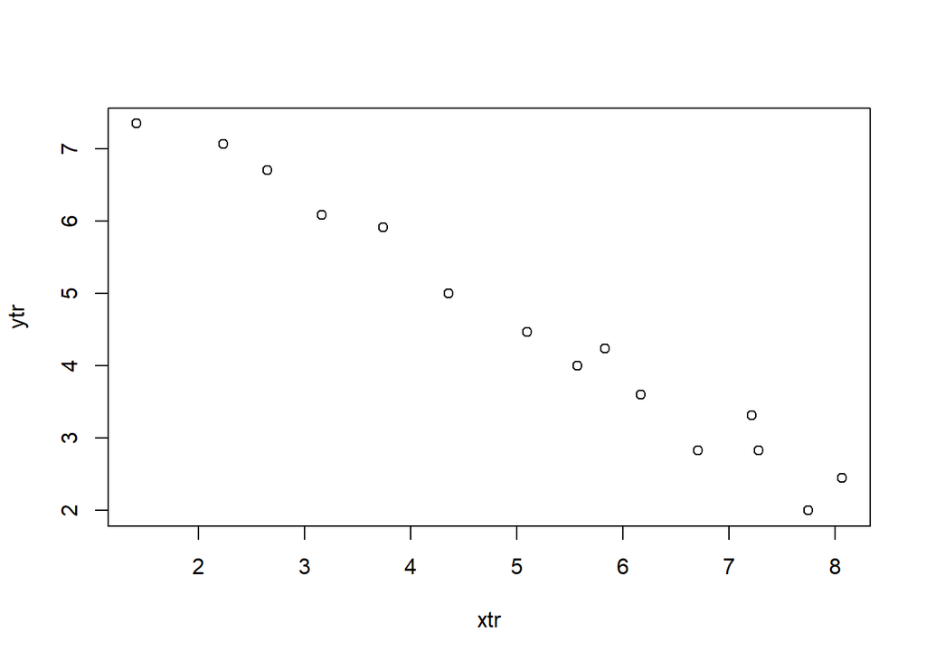

```r
ytr <- sqrt(data_ar$y)
xtr <- sqrt(data_ar$x)
plot(x=xtr, y=ytr)
```

# Model dan Pemeriksaan Asumsi

```r
model <- lm(ytr~xtr)
summary(model)
```

```
##
## Call:
## lm(formula = ytr ~ xtr)
##
## Residuals:
##      Min       1Q   Median       3Q      Max
## -0.42765 -0.17534 -0.05753  0.21223  0.46960
##
## Coefficients:
##             Estimate Std. Error t value Pr(>|t|)
## (Intercept)  8.71245    0.19101   45.61 9.83e-16 ***
## xtr         -0.81339    0.03445  -23.61 4.64e-12 ***
## ---
## Signif. codes:  0 '***' 0.001 '**' 0.01 '*' 0.05 '.' 0.1 ' ' 1
##
## Residual standard error: 0.2743 on 13 degrees of freedom
## Multiple R-squared:  0.9772, Adjusted R-squared:  0.9755
## F-statistic: 557.3 on 1 and 13 DF,  p-value: 4.643e-12
```

```r
lmtest::dwtest(model)
```

```
##
##  Durbin-Watson test
##
## data:  model
## DW = 2.6803, p-value = 0.8629
## alternative hypothesis: true autocorrelation is greater than 0
```

$$Dengan\ {\alpha}=0.05,\ dapat\
diputuskan\ bahwa\ H_0\ diterima\ karena\ (p-value=0.8629 >
{\alpha}=0.05), \ sehingga\ dapat\ diputuskan\ bahwa\ tidak\ ada\
autokorelasi\ dalam\ sisaan\ atau\ galat\ saling\ bebas.$$
Dengan demikian, diperoleh model terbaik diperoleh setelah melakukan transformasi pada variabel x dan y ke dalam bentuk akar yaitu sebagai berikut.
$$\hat{Y}=8.71245-0.81339X$$
Model ini telah memenuhi asumsi-asumsi dalam regresi linear